# Lesson 5

### Multivariate Data

Notes: Here we will do Data Analysis using not 2 but more variables.

### Load Data and packages

```r
library(ggplot2)
library(tidyr)
library(dplyr)
library(knitr)
library(reshape2)
pf <- read.csv("pseudo_facebook.tsv", sep = "\t")
```

### Third Qualitative Variable

Notes: Here we plot a boxplot for age by gender and also show the mean value for each group.

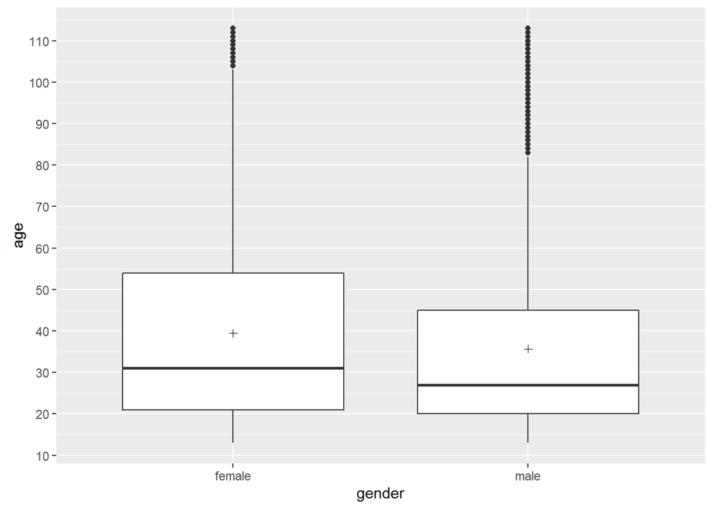

```r
ggplot(aes(x = gender, y = age), data = subset(pf, !is.na(gender))) +
  geom_boxplot() +
  geom_point(stat = "summary", fun.y = mean, shape = 3) +
  scale_y_continuous(breaks = seq(0, 113, 10))
```

Notes: Here we plot the median friend count for each gender

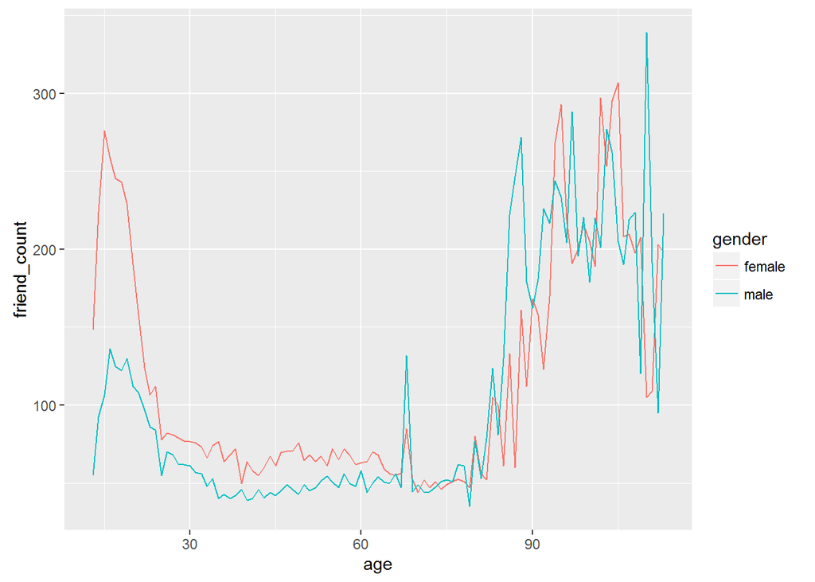

```r
ggplot(aes(x = age, y = friend_count),
                            data = subset(pf, !is.na(pf$gender))) +
  geom_line(aes(colour = gender), stat = "summary", fun.y = median)
```

Notes: Here we create a new data frame which has the mean and median friend count grouped by age and gender

```r
pf.fc_by_age_gender <- pf %>%
  filter(!is.na(pf$gender)) %>%
  group_by(age, gender) %>%
  summarise(mean_friend_count = mean(friend_count),
            median_friend_count = median(friend_count),
            n = n()) %>%
  ungroup() %>%
  arrange(age)
```

### Plotting Conditional Summaries

Notes:Here we plot median friend count using the new data frame that we just created above

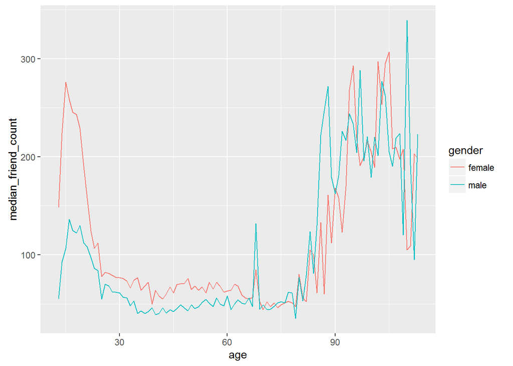

```r
ggplot(aes(y = median_friend_count, x = age, colour = gender),
       data = pf.fc_by_age_gender) +
  geom_line()
```

### Reshaping Data

Notes: Now we use the spread function of the tidyr package to change the columns of a our data frame.

```r
medianUsingDplyr <- pf.fc_by_age_gender[, c(1, 2, 4)] %>%
  spread(gender, median_friend_count)
```

Notes: Next we will use the reshape2 package to change the data from long to wide format

```r
medianUsingReshape <- dcast(pf.fc_by_age_gender, age ~ gender, value.var = "median_friend_count")
```

### Wide and Long Format

Notes: The wide format of the data contains columns for different categorical variables. The long format of the data has one columnn for multiple variable values.

### Ratio Plot

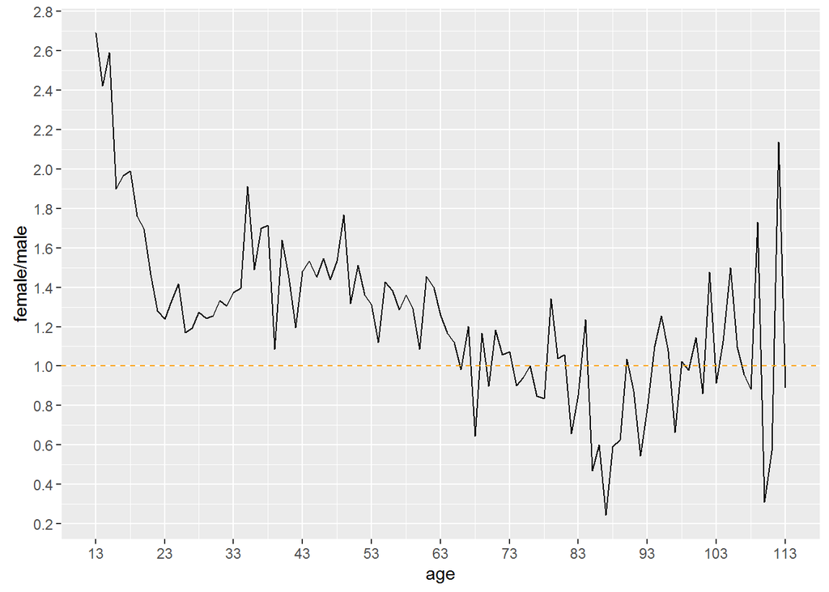

```r
ggplot(aes(x = age, y = female/male), data = medianUsingReshape) +
  geom_line() +
  geom_hline(yintercept = 1, lty = 2, colour = "orange") +
  scale_y_continuous(breaks = seq(0, 3, .2)) +
  scale_x_continuous(breaks = seq(13, 120, 10))
```

### Third Quantitative Variable

Notes: We will add a variable called year_joined to the data frame.

```r
pf$year_joined <- floor(2014 - pf$tenure/365)

summary(pf$year_joined)
```

```
##    Min. 1st Qu.  Median    Mean 3rd Qu.    Max.    NA's
##    2005    2012    2012    2012    2013    2014       2
```

```r
table(pf$year_joined)
```

```
##
##  2005  2006  2007  2008  2009  2010  2011  2012  2013  2014
##     9    15   581  1507  4557  5448  9860 33366 43588    70
```

### Cut a Variable

Notes: We add another variable year joined.bucket to the data frame. This variable bins together the year_joined column in different buckets.

```r
pf$year_joined.bucket <- cut(pf$year_joined, breaks = c(2004, 2009, 2011, 2012, 2014))

table(pf$year_joined.bucket, useNA = "ifany")
```

```
##
## (2004,2009] (2009,2011] (2011,2012] (2012,2014]        <NA>
##        6669       15308       33366       43658           2
```

### Plotting it All Together

Notes:We now plot the median friend count vs age for each of the different year_joined.bucket bins.

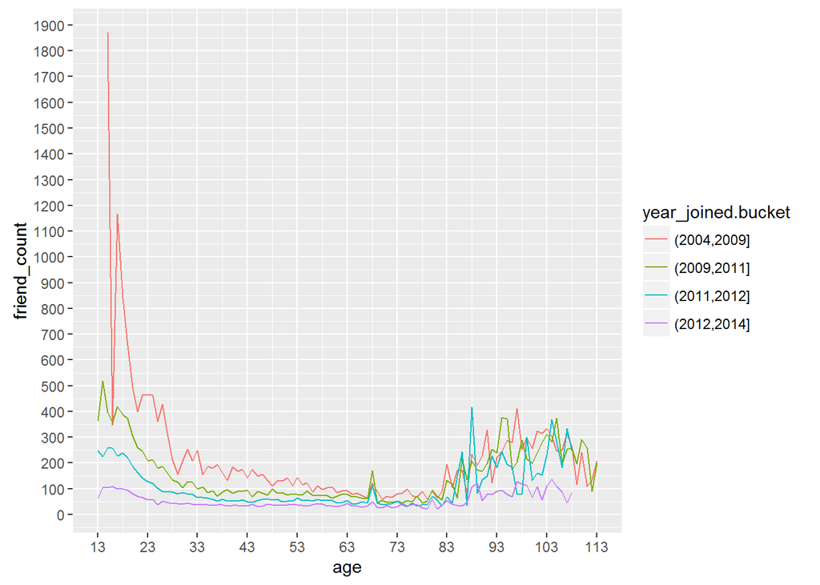

```r
ggplot(aes(x = age, y = friend_count),
       data = subset(pf, !is.na(pf$year_joined.bucket))) +
  geom_line(aes(colour = year_joined.bucket), stat = "summary", fun.y = median) +
  scale_y_continuous(breaks = seq(0, 2000, 100)) +
  scale_x_continuous(breaks = seq(13, 120, 10))
```

### Plot the Grand Mean

Notes:Plot showing friend count vs age for each of the different year joined bucket bins.

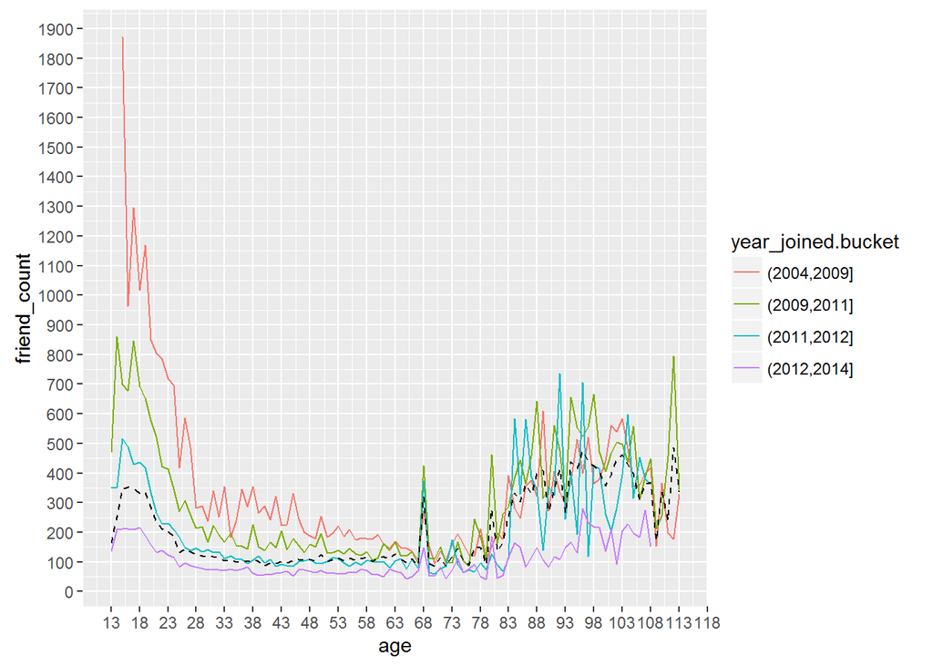

```r
ggplot(aes(x = age, y = friend_count),
       data = subset(pf, !is.na(pf$year_joined.bucket))) +
  geom_line(aes(colour = year_joined.bucket), stat = "summary",
            fun.y = mean) +
  geom_line(stat = "summary", fun.y = mean, lty = 2) +
  scale_y_continuous(breaks = seq(0, 2000, 100)) +
  scale_x_continuous(breaks = seq(13, 120, 5))
```

### Friending Rate

Notes:Calculating the friend count for the number of days active on facebook excluding the tenure of 0 days.

```r
with(subset(pf, pf$tenure > 0), summary(friend_count / tenure))
```

```
##     Min.  1st Qu.   Median     Mean  3rd Qu.     Max.
##   0.0000   0.0775   0.2205   0.6096   0.5658 417.0000
```

What is the median friend rate? - 0.2205

What is the maximum friend rate? - 417 ***

### Friendships Initiated

Notes:Below is a plot that shows friendsjhips initiated by tenure

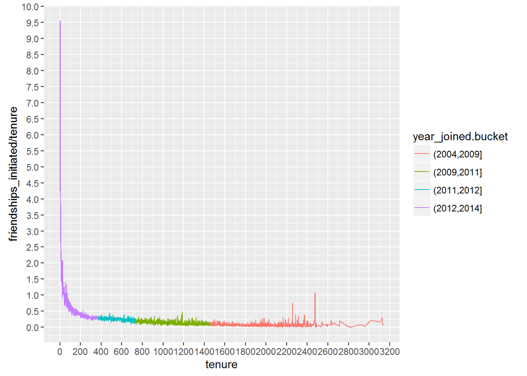

```r
pf %>%
  filter(tenure > 0) %>%
  ggplot(aes(x = tenure, y = friendships_initiated / tenure)) +
  geom_line(aes(colour = year_joined.bucket), stat = "summary", fun.y = mean) +
  scale_y_continuous(breaks = seq(0, 10, .5)) +
  scale_x_continuous(breaks = seq(0, 3200, 200))
```

### Bias-Variance Tradeoff Revisited

Notes:Here we plot the friend rate vs tenure for different bin widths. Finally we add a smoothner to the plot.

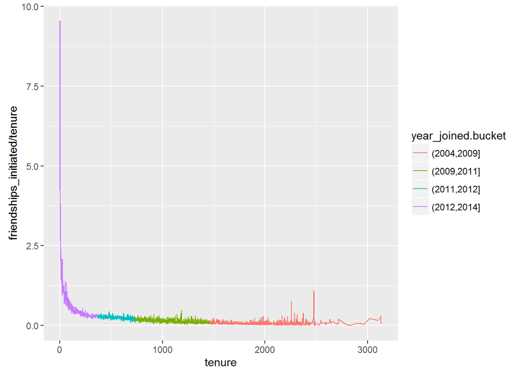

```r
ggplot(aes(x = tenure, y = friendships_initiated / tenure),
       data = subset(pf, tenure >= 1)) +
  geom_line(aes(color = year_joined.bucket),
            stat = 'summary',
            fun.y = mean)
```

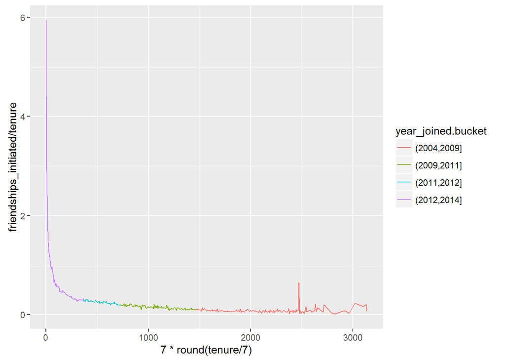

```r
ggplot(aes(x = 7 * round(tenure / 7), y = friendships_initiated / tenure),
       data = subset(pf, tenure > 0)) +
  geom_line(aes(color = year_joined.bucket),
            stat = "summary",
            fun.y = mean)
```

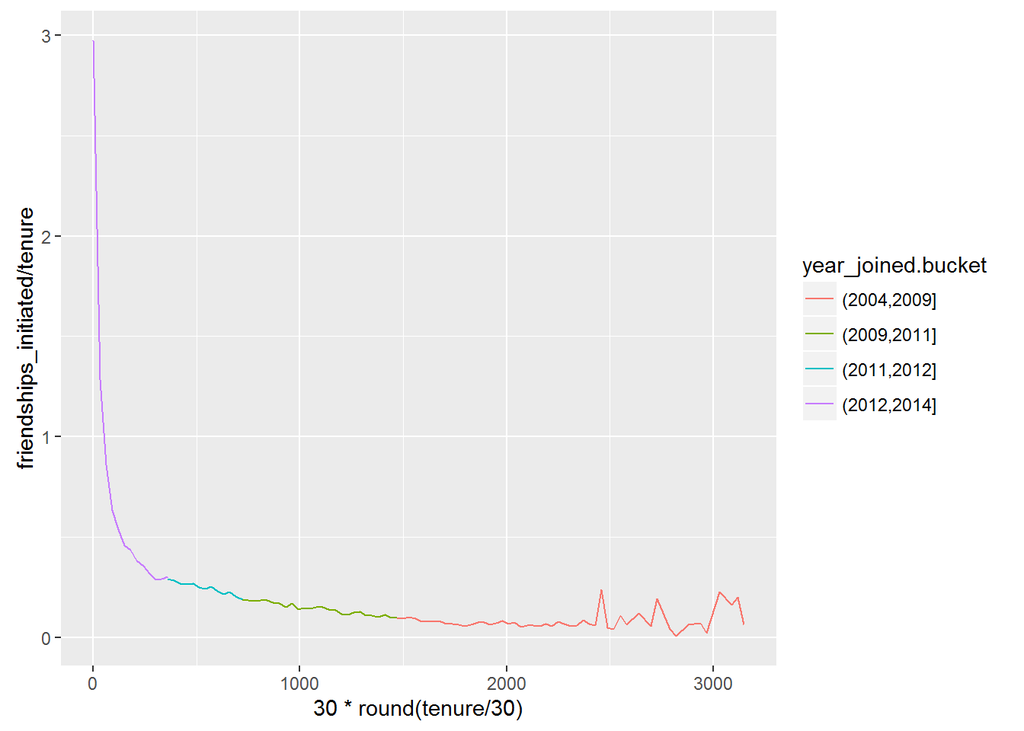

```r
ggplot(aes(x = 30 * round(tenure / 30), y = friendships_initiated / tenure),
       data = subset(pf, tenure > 0)) +
  geom_line(aes(color = year_joined.bucket),
            stat = "summary",
            fun.y = mean)
```

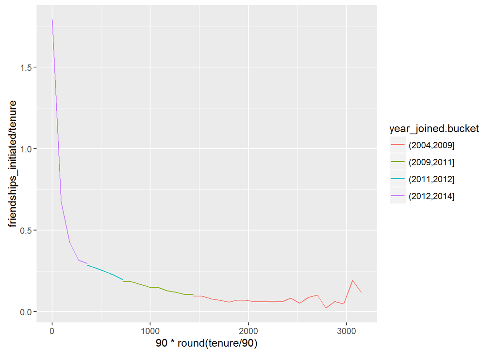

```r
ggplot(aes(x = 90 * round(tenure / 90), y = friendships_initiated / tenure),
       data = subset(pf, tenure > 0)) +
  geom_line(aes(color = year_joined.bucket),
            stat = "summary",
            fun.y = mean)
```

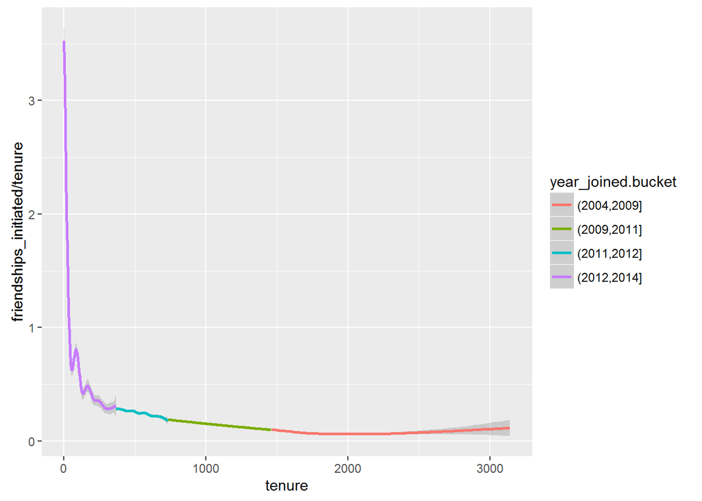

```r
ggplot(aes(x = tenure, y = friendships_initiated / tenure),
       data = subset(pf, pf$tenure > 0)) +
  stat_smooth(aes(colour = year_joined.bucket))
```

### Introducing the Yogurt Data Set

Notes:Load the data and convert id variable into a factor

```r
yo <- read.csv("yogurt.csv")
yo$id <- as.factor(yo$id)
```

### Histograms Revisited

Notes:Lots of gaps in the histogram plot. Most of the yogurt bought is in the 65-70 price range.

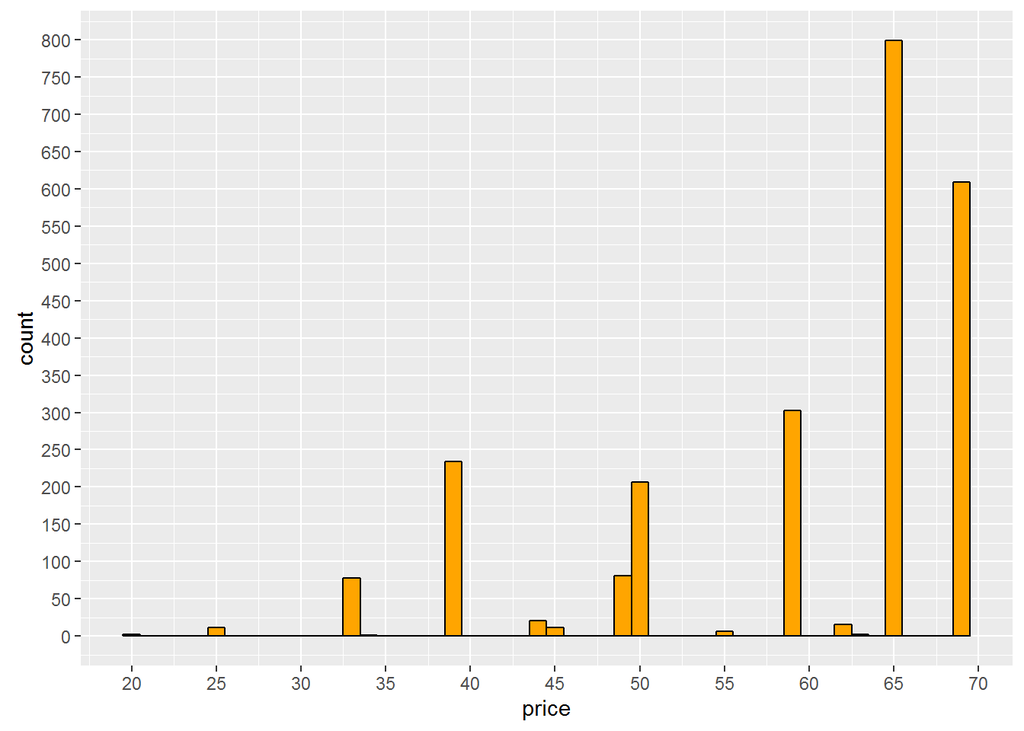

```r
ggplot(aes(x = price), data = yo) +
  geom_histogram(binwidth = 1, colour = "black", fill = "orange") +
  scale_x_continuous(breaks = seq(0, 75, 5)) +
  scale_y_continuous(breaks = seq(0, 800, 50))
```

### Number of Purchases

Notes:We add a column to the data frame. This new column contains the sum of all yogurt purchases for an observation.

```r
yo <- transform(yo, all.purchases = strawberry + blueberry + pina.colada + plain + mixed.berry)
```

### Prices over Time

Notes:We create a scatter plot of price vs time and see that price of the yogurt bought increases over time

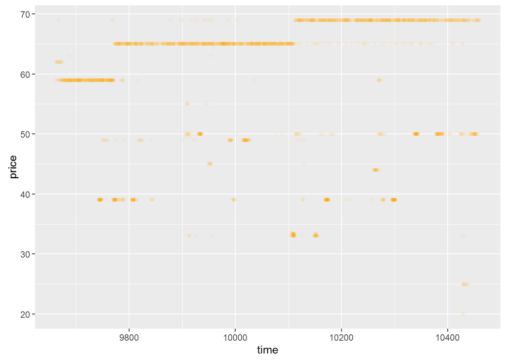

```r
ggplot(aes(x = time, y = price), data = yo) +
  geom_jitter(alpha = 1/20, colour = "orange")
```

### Sampling Observations

Notes:It is often useful to work with a sample of the data set to get a better feel of the general pattern of the data.

### Looking at Samples of Households

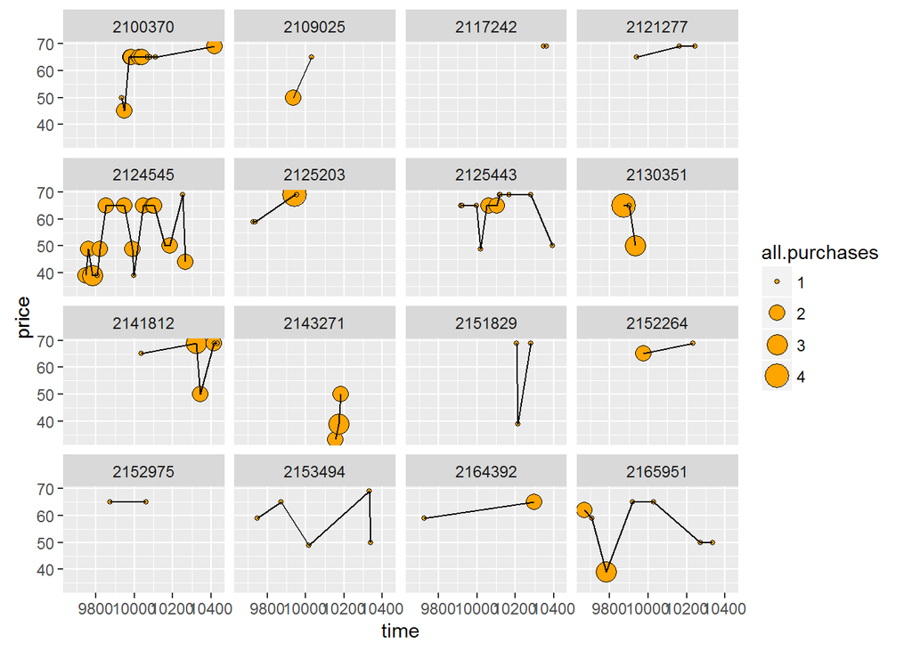

```r
set.seed(77)
sample.ids <- sample(levels(yo$id), 16)

ggplot(aes(x = time, y = price), data = subset(yo, id %in% sample.ids)) +
  geom_point(aes(size = all.purchases), pch = 21, col = "black", fill = "orange") +
  geom_line() +
  facet_wrap( ~ id)
```

Above we have randomly selected 16 different ids from the data set. Before this we had made id as a factor because the id variable shows the different purchases of the same buyer. Next we have plotted the price vs time scatter plot for the selected 16 ids and faceted over ids. Since we have used the id variable as a factor therefore we can facet the plot over id. We have also mapped all.purchases to size in the aesthetics of the geom point. From this we can see that the bigger the size of the point more the yogurt was bought by that id. For example for id 2124545 starting from the begining the buyer bought 2 yogurts then 2, then 3, then 1 and so on. ***

### The Limits of Cross Sectional Data

Notes: Cross sectional data does not provide us the ability to to study same values of one varaible for different values of another variable

### Heat Maps

Notes:Herw we plot a Heat map for gene data. The data set has close to 7000 observations but we plot this for 200 observations

```r
nci <- read.table("nci.tsv")
colnames(nci) <- c(1:64)
```

```r
nci.long.samp <- melt(as.matrix(nci[1:200, ]))
names(nci.long.samp) <- c("gene", "case", "value")
head(nci.long.samp)
```

```
##   gene case  value
## 1    1    1  0.300
## 2    2    1  1.180
## 3    3    1  0.550
## 4    4    1  1.140
## 5    5    1 -0.265
## 6    6    1 -0.070
```

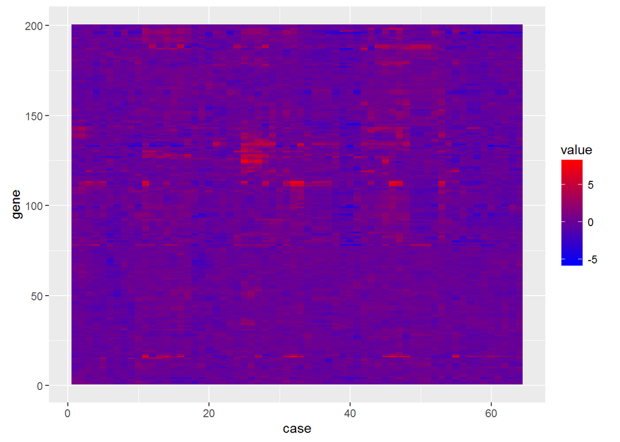

```r
ggplot(aes(y = gene, x = case, fill = value),
  data = nci.long.samp) +
  geom_tile() +
  scale_fill_gradientn(colours = colorRampPalette(c("blue", "red"))(100))
```